# Artificial Intelligence and Machine Learning

# Now from subspace to the Input space

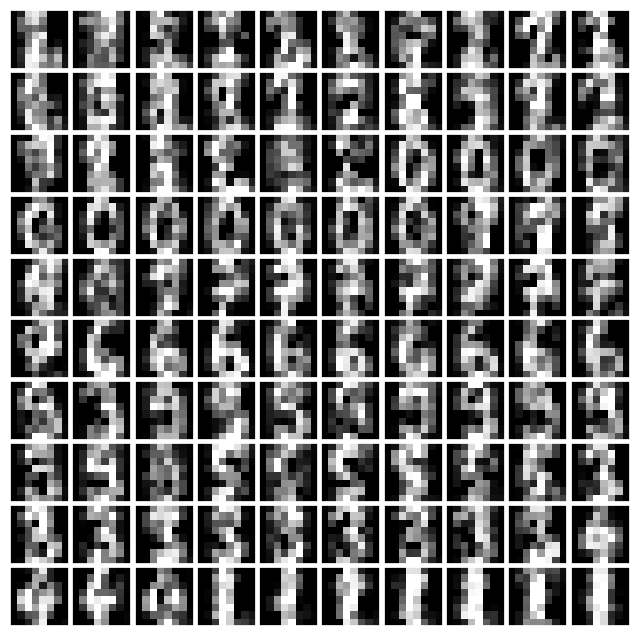

```python
digits_new = pca.inverse_transform(data_new)
plot_digits(digits_new)
```

# These digits *[should]* not exist in the initial dataset!

# GMM Model Debug

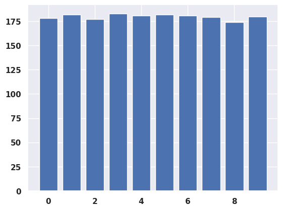

```python
plt.bar(*np.unique(digits.target, return_counts=True));
```

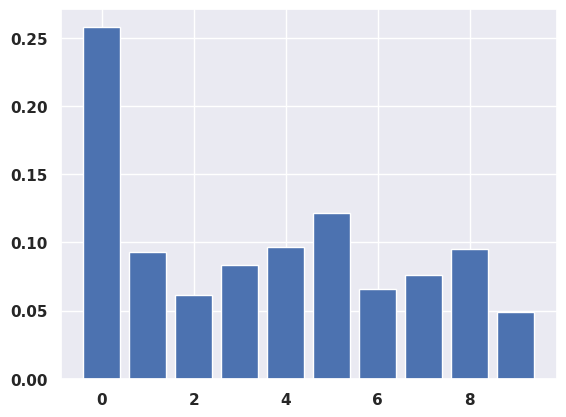

```python
plt.bar(range(10),model.weights_);    # weights are actually the -mixing coefficients-
```

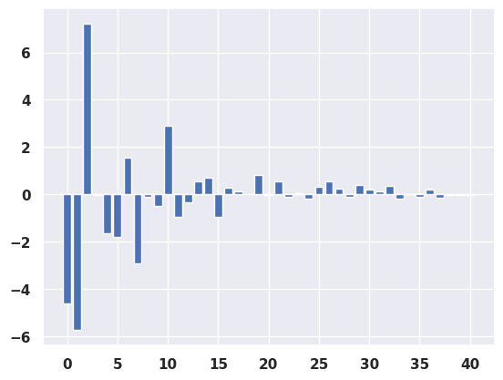

```python
plt.bar(range(model.means_[0].shape[0]),model.means_[0]);
```

# For example, you can check if the mean is very close to a training point

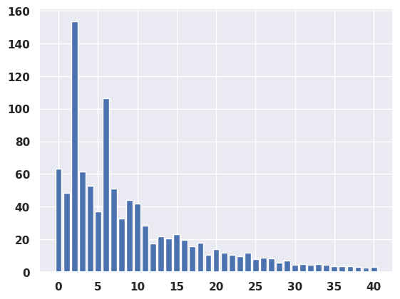

```python
plt.bar(range(model.means_[0].shape[0]),model.covariances_[0]);
```

# You could debug covariance to spot potential singularities (though sklearn may avoid that)

# Homework 3

- Fit a GMM "manually" using the labels provided by `digits.target` with `K=10`
- Fit now the same GMM without labels and debug/confront the parameters of the models
- Try to draw some conclusions regarding the difference